# Toy Models

Niels Richard Hansen

This vignette demonstrates the functionality of ppstat. It uses the simulated toyData to illustrate how some toy models can be specified and how the fitted models can be visualized.

```r
library(ppstat)
```

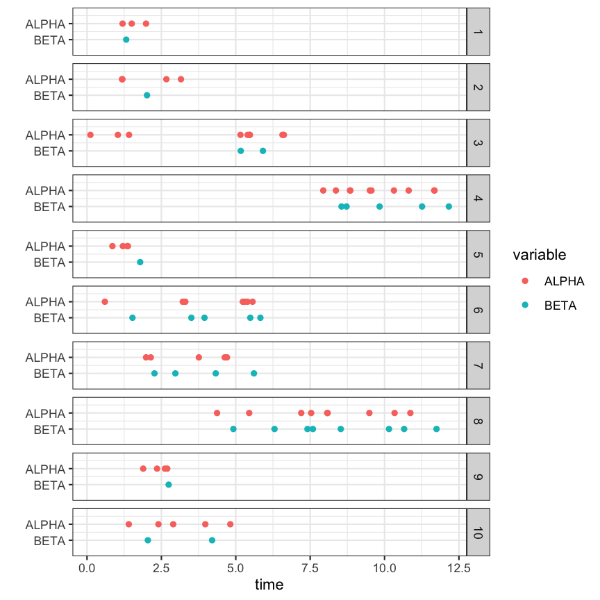

```r
data(toyData)
plot(toyData)
```

```r
toyPPM <- pointProcessModel(BETA ~ bSpline(ALPHA, knots = seq(-1, 2.5, 0.5)),
                            data = toyData,
                            family = Hawkes(),
                            support = 2)
summary(toyPPM)
```

```
##
## Call:
## pointProcessModel(formula = BETA ~ bSpline(ALPHA, knots = seq(-1,
##     2.5, 0.5)), data = toyData, family = Hawkes(), support = 2)
##
##
## Coefficients:
##                      Estimate Std. Error z value Pr(> |z|)
## (Intercept)        -1.523e-09  3.281e-01   0.000     1.000
## bSpline(ALPH...))1  1.294e-01  1.999e-01   0.647     0.517
## bSpline(ALPH...))2  5.380e-01  2.254e-01   2.387     0.017 *
## bSpline(ALPH...))3  2.210e-01  1.991e-01   1.110     0.267
## bSpline(ALPH...))4 -2.685e-01  1.678e-01  -1.601     0.109
## ---
## Signif. codes:  0 '***' 0.001 '**' 0.01 '*' 0.05 '.' 0.1 ' ' 1
##
## Minus-log-likelihood: 27.589 on 5 degrees of freedom
## AIC: 65.177
##
## Number of function evaluations: 125
## Number of gradient evaluations: 16
```

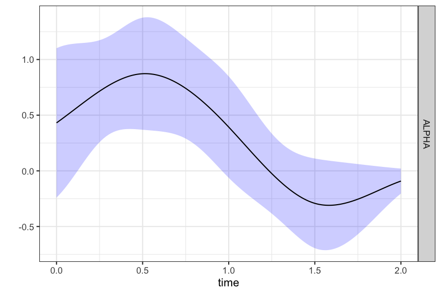

```r
termPlot(toyPPM)
```

Alternative analysis. The filter function is composed of two constant components.

```r
toyPPM <- pointProcessModel(BETA ~ cut(ALPHA, c(0, 1, 2),
                                       include.lowest = TRUE),
                            data = toyData,
                            family = Hawkes(),
                            support = 2)
summary(toyPPM)
```

```
##
## Call:
## pointProcessModel(formula = BETA ~ cut(ALPHA, c(0, 1, 2), include.lowest = TRUE),
##     data = toyData, family = Hawkes(), support = 2)
##
##
## Coefficients:
##                      Estimate Std. Error z value Pr(> |z|)
## (Intercept)        -9.820e-08  4.376e-01   0.000   1.00000
## cut(ALPHA, c...,1]  7.223e-01  2.711e-01   2.664   0.00772 **
## cut(ALPHA, c...,2] -1.928e-01  1.741e-01  -1.107   0.26825
## ---
## Signif. codes:  0 '***' 0.001 '**' 0.01 '*' 0.05 '.' 0.1 ' ' 1
##
## Minus-log-likelihood: 25.787 on 3 degrees of freedom
## AIC: 57.575
##
## Number of function evaluations: 154
## Number of gradient evaluations: 21
```

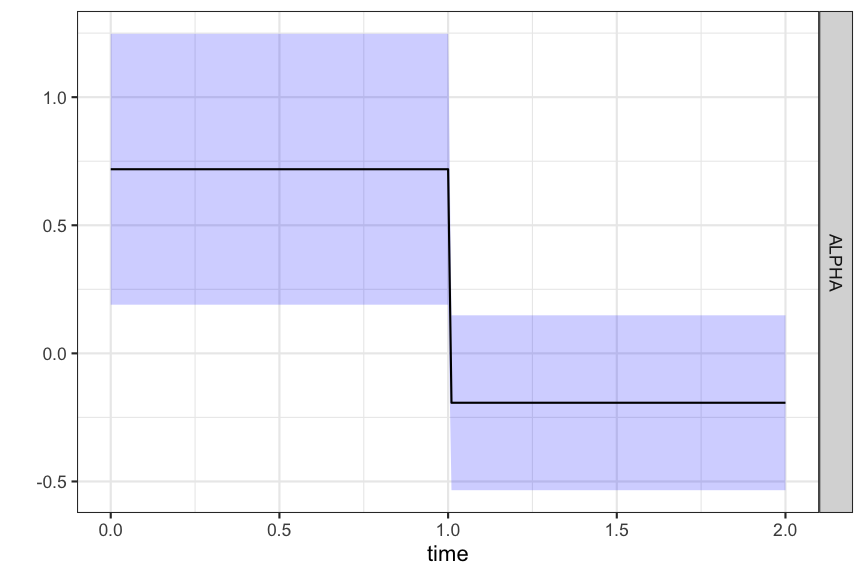

```r
termPlot(toyPPM)
```

Use of `I()` is required to make constructs like `(ALPHA <= 1)` work correctly!

```r
toyPPM <- pointProcessModel(BETA ~ I(ALPHA <= 1),
                            data = toyData,
                            family = Hawkes(),
                            support = 2)
summary(toyPPM)
```

```
##
## Call:
## pointProcessModel(formula = BETA ~ I(ALPHA <= 1), data = toyData,
##     family = Hawkes(), support = 2)
##
##
## Coefficients:
##                      Estimate Std. Error z value Pr(> |z|)
## (Intercept)        -9.820e-08  4.376e-01   0.000   1.00000
## I(ALPHA <= 1)FALSE -1.928e-01  1.741e-01  -1.107   0.26825
## I(ALPHA <= 1)TRUE   7.223e-01  2.711e-01   2.664   0.00772 **
## ---
## Signif. codes:  0 '***' 0.001 '**' 0.01 '*' 0.05 '.' 0.1 ' ' 1
##
## Minus-log-likelihood: 25.787 on 3 degrees of freedom
## AIC: 57.575
##
## Number of function evaluations: 154
## Number of gradient evaluations: 21
```

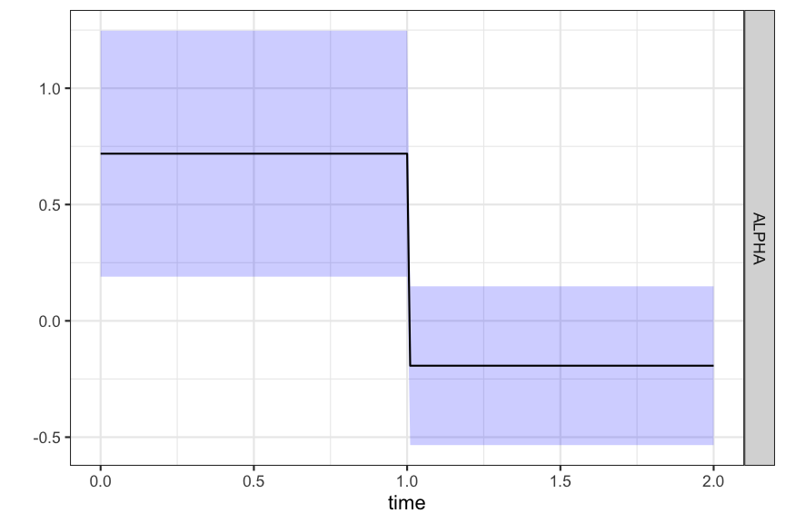

```r
termPlot(toyPPM)
```

But the behavior above is perhaps not as expected. The result is a model equivalent to the model using `cut()` above. To get the indicator function for the interval $[0,1]$, use the formula below.

```r
toyPPM <- pointProcessModel(BETA ~ as.numeric(ALPHA <= 1),
                            family = Hawkes(),
                            data = toyData,
                            support = 2)
summary(toyPPM)
```

```
##
## Call:
## pointProcessModel(formula = BETA ~ as.numeric(ALPHA <= 1), data = toyData,
##     family = Hawkes(), support = 2)
##
##
## Coefficients:
##                      Estimate Std. Error z value Pr(> |z|)
## (Intercept)        -2.235e-08  4.160e-01   0.000    1.0000
## as.numeric(A... 1)  6.594e-01  2.744e-01   2.403    0.0162 *
## ---
## Signif. codes:  0 '***' 0.001 '**' 0.01 '*' 0.05 '.' 0.1 ' ' 1
##
## Minus-log-likelihood: 26.465 on 2 degrees of freedom
## AIC: 56.93
##
## Number of function evaluations: 138
## Number of gradient evaluations: 22
```

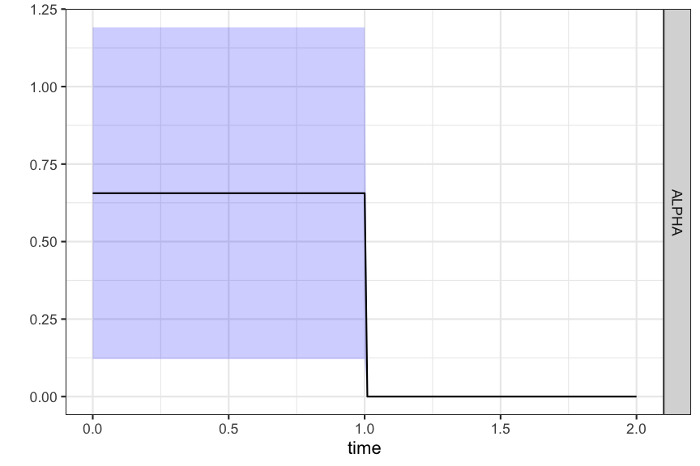

```r
termPlot(toyPPM)
```

We can include self-dependence of the BETA-points, and a time trend.

```r
toyPPM <- pointProcessModel(BETA ~ time + bSpline(ALPHA, knots = seq(-1, 2.5, 0.5)) +
                            bSpline(BETA, knots = seq(-1, 2.5, 0.5)),
                            data = toyData,
                            family = Hawkes(),
                            support = 2)
summary(toyPPM)
```

```
##
## Call:
## pointProcessModel(formula = BETA ~ time + bSpline(ALPHA, knots = seq(-1,
##     2.5, 0.5)) + bSpline(BETA, knots = seq(-1, 2.5, 0.5)), data = toyData,
##     family = Hawkes(), support = 2)
##
##
## Coefficients:
##                    Estimate Std. Error z value Pr(> |z|)
## (Intercept)        -0.80074    0.29482  -2.716  0.006607 **
## time                0.18743    0.06156   3.045  0.002329 **
## bSpline(ALPH...))1  0.40464    0.15491   2.612  0.008999 **
## bSpline(ALPH...))2  0.64812    0.20607   3.145  0.001660 **
## bSpline(ALPH...))3  0.77378    0.23568   3.283  0.001026 **
## bSpline(ALPH...))4 -0.80049    0.27746  -2.885  0.003914 **
## bSpline(BETA...))1 -0.84966    0.23400  -3.631  0.000282 ***
## bSpline(BETA...))2 -1.06785    0.32487  -3.287  0.001012 **
## bSpline(BETA...))3 -0.26129    0.23468  -1.113  0.265532
## bSpline(BETA...))4 -0.03646    0.22162  -0.165  0.869331
## ---
## Signif. codes:  0 '***' 0.001 '**' 0.01 '*' 0.05 '.' 0.1 ' ' 1
##
## Minus-log-likelihood: 17.108 on 10 degrees of freedom
## AIC: 54.216
##
## Number of function evaluations: 52
## Number of gradient evaluations: 22
```

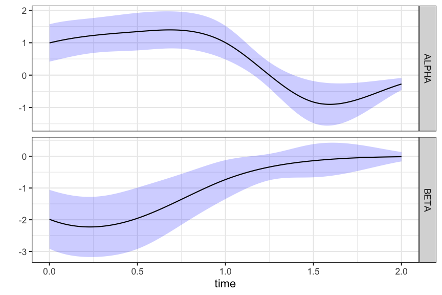

```r
termPlot(toyPPM)
```

We can change the `link()` function to the log-link.

```r
toyPPM <- pointProcessModel(BETA ~ time + bSpline(ALPHA, knots = seq(-1, 2.5, 0.5)) +
                            bSpline(BETA, knots = seq(-1, 2.5, 0.5)),
                            data = toyData,
                            family = Hawkes("log"),
                            support = 2)
summary(toyPPM)
```

```
##
## Call:
## pointProcessModel(formula = BETA ~ time + bSpline(ALPHA, knots = seq(-1,
##     2.5, 0.5)) + bSpline(BETA, knots = seq(-1, 2.5, 0.5)), data = toyData,
##     family = Hawkes("log"), support = 2)
##
##
## Coefficients:
##                    Estimate Std. Error z value Pr(> |z|)
## (Intercept)        -2.58631    0.51103  -5.061  4.17e-07 ***
## time                0.31764    0.07847   4.048  5.16e-05 ***
## bSpline(ALPH...))1  0.20864    0.17815   1.171   0.24154
## bSpline(ALPH...))2  0.54586    0.20996   2.600   0.00933 **
## bSpline(ALPH...))3  0.74201    0.33301   2.228   0.02587 *
## bSpline(ALPH...))4 -1.24549    0.42941  -2.900   0.00373 **
## bSpline(BETA...))1 -0.90563    0.52888  -1.712   0.08683 .
## bSpline(BETA...))2 -1.17350    0.56982  -2.059   0.03945 *
## bSpline(BETA...))3 -0.29411    0.49199  -0.598   0.54998
## bSpline(BETA...))4  0.34053    0.37782   0.901   0.36743
## ---
## Signif. codes:  0 '***' 0.001 '**' 0.01 '*' 0.05 '.' 0.1 ' ' 1
##
## Minus-log-likelihood: 20.177 on 10 degrees of freedom
## AIC: 60.354
##
## Number of function evaluations: 52
## Number of gradient evaluations: 19
```

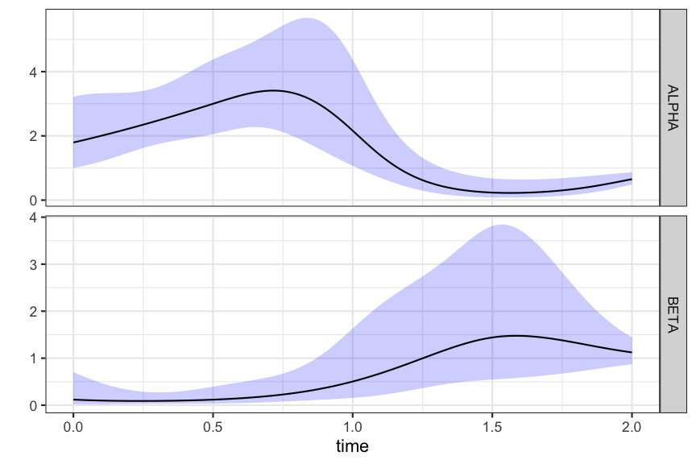

```r
termPlot(toyPPM, trans = exp)
```

The Gibbs family allows for anticipation in the linear filter.

```r
toyPPM <- pointProcessModel(BETA ~ bSpline(ALPHA, knots = seq(-2.5, 2.5, 0.5)),
                            data = toyData,
                            family = Gibbs(),
                            support = c(-2, 2))
summary(toyPPM)
```

```
##
## Call:
## pointProcessModel(formula = BETA ~ bSpline(ALPHA, knots = seq(-2.5,
##     2.5, 0.5)), data = toyData, family = Gibbs(), support = c(-2,
##     2))
##
##
## Coefficients:
##                    Estimate Std. Error z value Pr(> |z|)
## (Intercept)        -0.11232    0.07555  -1.487    0.1371
## bSpline(ALPH...))1  0.11600    0.06651   1.744    0.0811 .
## bSpline(ALPH...))2 -0.23722    0.10724  -2.212    0.0270 *
## bSpline(ALPH...))3  0.24911    0.10602   2.350    0.0188 *
## bSpline(ALPH...))4 -0.14175    0.09571  -1.481    0.1386
## bSpline(ALPH...))5  0.70062    0.16033   4.370  1.24e-05 ***
## bSpline(ALPH...))6  0.16252    0.12099   1.343    0.1792
## bSpline(ALPH...))7 -0.20080    0.10238  -1.961    0.0498 *
## ---
## Signif. codes:  0 '***' 0.001 '**' 0.01 '*' 0.05 '.' 0.1 ' ' 1
##
## Minus-log-likelihood: 27.549 on 8 degrees of freedom
## AIC: 71.098
##
## Number of function evaluations: 94
## Number of gradient evaluations: 23
```

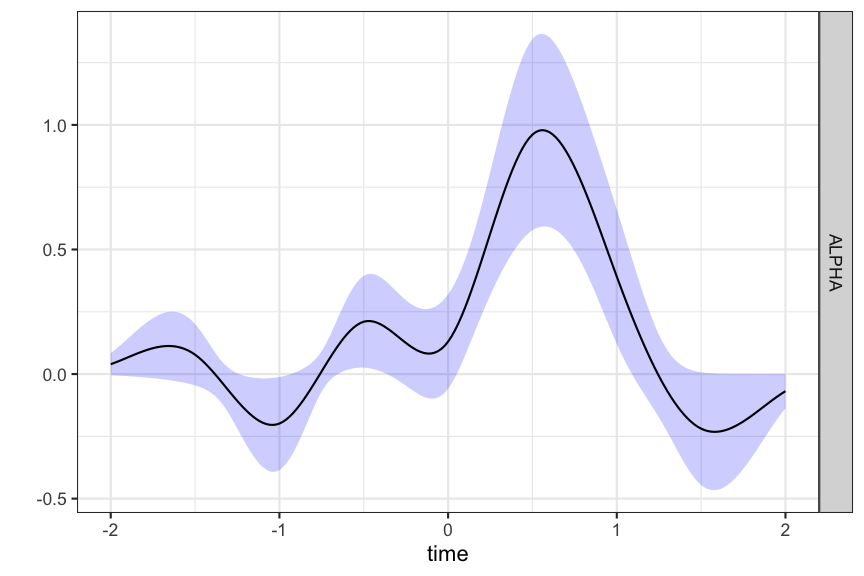

```r
termPlot(toyPPM)
```

For the Gibbs family the filter function can be made symmetric, if the basis functions are. Using `bSpline()` this is achieved as follows.

```r
toyPPM <- pointProcessModel(BETA ~ bSpline(ALPHA, knots = seq(-2.5, 2.5, 0.5), sym = TRUE),
                            data = toyData,
                            family = Gibbs(),
                            support = c(-2, 2))
summary(toyPPM)
```

```
##
## Call:
## pointProcessModel(formula = BETA ~ bSpline(ALPHA, knots = seq(-2.5,
##     2.5, 0.5), sym = TRUE), data = toyData, family = Gibbs(),
##     support = c(-2, 2))
##
##
## Coefficients:
##                      Estimate Std. Error z value Pr(> |z|)
## (Intercept)         2.383e-08  5.358e-05   0.000   0.99965
## bSpline(ALPH...E)1 -5.567e-01  2.086e-01  -2.668   0.00762 **
## bSpline(ALPH...E)2  6.634e-01  2.393e-01   2.772   0.00556 **
## bSpline(ALPH...E)3 -3.016e-01  1.376e-01  -2.191   0.02842 *
## bSpline(ALPH...E)4  5.930e-02  1.167e-01   0.508   0.61126
## bSpline(ALPH...E)5  4.106e-01  1.016e-01   4.042  5.31e-05 ***
## ---
## Signif. codes:  0 '***' 0.001 '**' 0.01 '*' 0.05 '.' 0.1 ' ' 1
##
## Minus-log-likelihood: 33.952 on 6 degrees of freedom
## AIC: 79.905
##
## Number of function evaluations: 94
## Number of gradient evaluations: 26
```

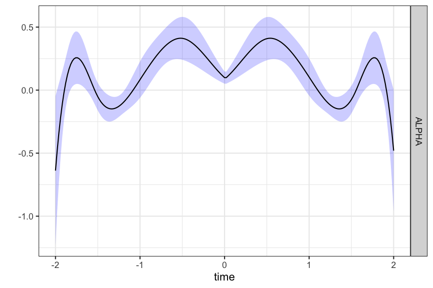

```r
termPlot(toyPPM)
```

For the model to be a valid model of the point process, self-dependence terms are not allowed to be anticipating. It is valid for other terms to be anticipating, and using the Gibbs family we can specify such a model.

WARNING: When using the Gibbs family it is entirely up to the user to make sure that the filter function for the self-dependence term is 0 on the negative axis. Using `bSpline()` we set `trunc = 0` to truncate the basis expansion at 0.

```r
toyPPM <- pointProcessModel(BETA ~ bSpline(BETA, knots = seq(-2.5, 2.5, 1), trunc = 0) +
                            bSpline(ALPHA, knots = seq(-2.5, 2.5, 1), trunc = c(-2, 2)),
                            data = toyData,
                            family = Gibbs(),
                            support = c(-2, 2))
summary(toyPPM)
```

```
##
## Call:
## pointProcessModel(formula = BETA ~ bSpline(BETA, knots = seq(-2.5,
##     2.5, 1), trunc = 0) + bSpline(ALPHA, knots = seq(-2.5, 2.5,
##     1), trunc = c(-2, 2)), data = toyData, family = Gibbs(),
##     support = c(-2, 2))
##
##
## Coefficients:
##                    Estimate Std. Error z value Pr(> |z|)
## (Intercept)        -0.13775    0.06302  -2.186    0.0288 *
## bSpline(BETA...0)1 -0.51595    0.10683  -4.830  1.37e-06 ***
## bSpline(BETA...0)2 -0.40248    0.19750  -2.038    0.0416 *
## bSpline(ALPH...))1 -0.11925    0.06320  -1.887    0.0592 .
## bSpline(ALPH...))2  0.93198    0.18252   5.106  3.29e-07 ***
## ---
## Signif. codes:  0 '***' 0.001 '**' 0.01 '*' 0.05 '.' 0.1 ' ' 1
##
## Minus-log-likelihood: 25.849 on 5 degrees of freedom
## AIC: 61.699
##
## Number of function evaluations: 75
## Number of gradient evaluations: 19
```

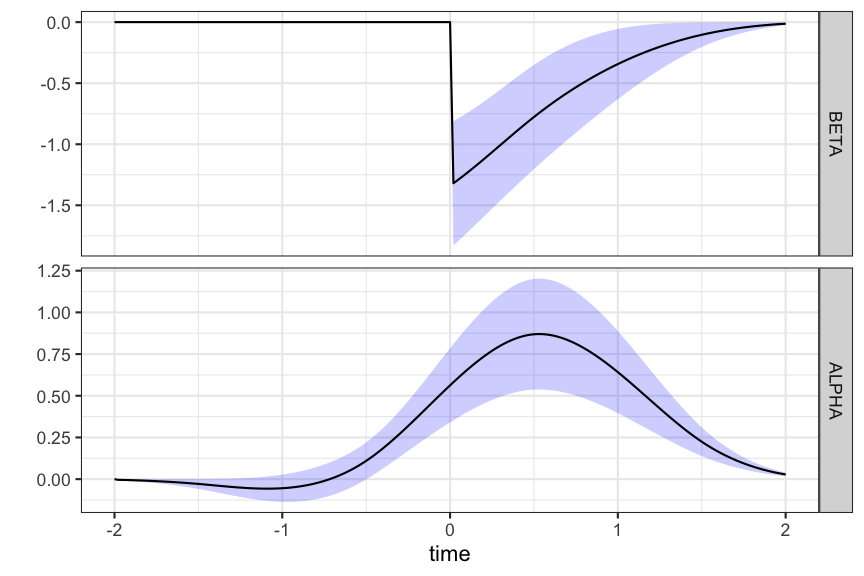

```r
termPlot(toyPPM)
```

Multivariate models can by specified by letting the left hand side of the formula be a vector of symbols. There is a stepwise model selection algorithm for selecting a submodel based on an information criteria.

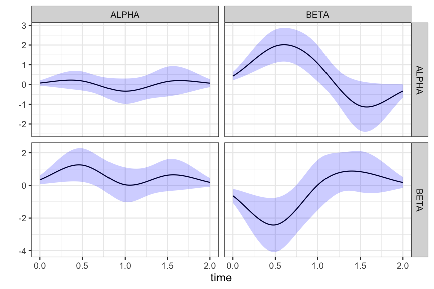

```r
toyPPM <- pointProcessModel(c(ALPHA, BETA) ~
                              bSpline(ALPHA, knots = seq(-0.5, 2.5, 0.5)) +
                              bSpline(BETA, knots = seq(-0.5, 2.5, 0.5)),
                            data = toyData,
                            family = Hawkes("logaffine"),
                            support = 2)
termPlot(toyPPM)
```

```r
toyPPM <- stepInformation(toyPPM)
```

```
##  Step      AIC        Direction
##   1   113.2504     start
##   2   108.8472     backward
##  Step      AIC        Direction
##   1   67.85557     start
```

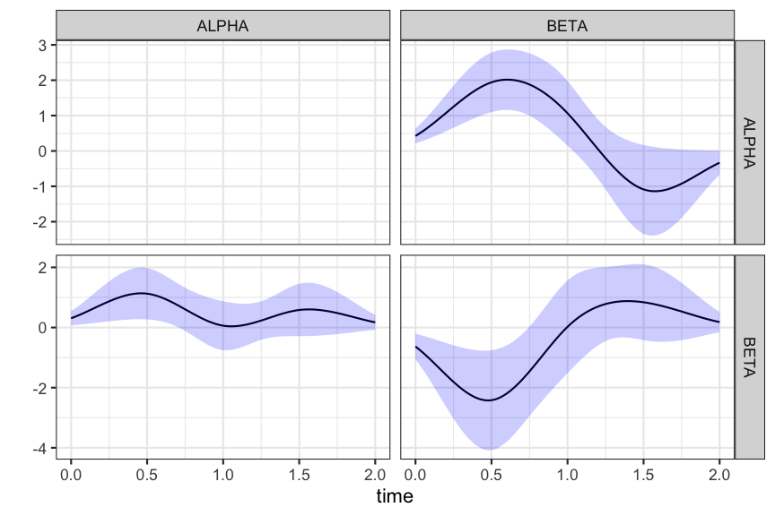

```r
termPlot(toyPPM)
```

Terms can also be specified using a smoother and a penalty parameter.

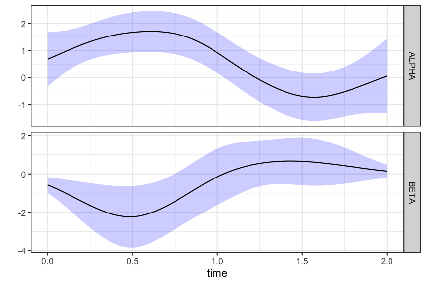

```r
toyPPM <- ppSmooth(BETA ~ s(ALPHA) +
                     bSpline(BETA, knots = seq(-0.5, 2.5, 0.5)),
                   data = toyData,
                   family = Hawkes("logaffine"),
                   support = 2,
                   lambda = 0.1)
termPlot(toyPPM)
```

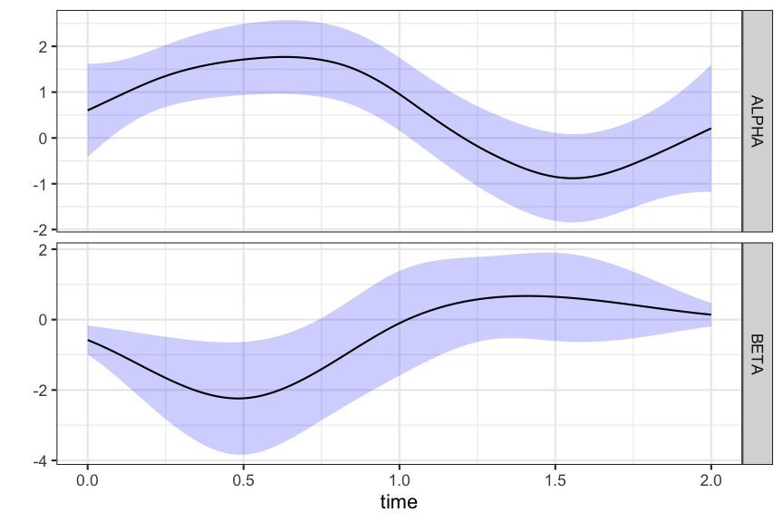

```r
toyPPM <- ppKernel(BETA ~ k(ALPHA) +
                     bSpline(BETA, knots = seq(-0.5, 2.5, 0.5)),
                   data = toyData,
                   family = Hawkes("logaffine"),
                   support = 2,
                   lambda = 0.01)
termPlot(toyPPM)
```